# Final test on quantitative methods

Data and statistics with R Research methods

Jüri Lillemets

2019-10-02

Type your commands and comments in an R script. For actions type respective commands in R. For questions provide answers as comments. Submit the R script in Moodle once you’re finished.

Answer the questions as comprehensively as you can. Use complete sentences. If relevant, explain your understanding in the context of hypothesis testing.

# 1 Data import and overview

1. Read data on the *url* below. (1 pt)  
   https://raw.githubusercontent.com/lillemets/datastatsr/master/data/verbyla_lupin.csv
2. Store this data as data frame. (1 pt)

The variables are described as follows:

**Edit on 30.09.19: Variable `harvest` is actually `yield`. For excercises below, it was necessary to type `yield` instead of `harvest`.**

The following tasks involve comparing harvest by location and replication, and investingating relationship between harvest and seeding rate.

3. See the first rows of data. (1 pt)

```r
head(lupin)
```

```
##           gen site rep rate row col serp linrow lincol    linrate  yield
## 97  Illyarrie  S02  R1   40   1   1  SE1  -0.75   -2.5 -0.1694215 1.1674
## 98   Gungurru  S02  R1   60   2   1  SE2  -0.65   -2.5  1.8305785 1.7718
## 99     Merrit  S02  R1   40   3   1  SE3  -0.55   -2.5 -0.1694215 1.2966
## 100  Gungurru  S02  R1   50   4   1  SE4  -0.45   -2.5  0.8305785 2.0379
## 101  Gungurru  S02  R1   40   5   1  SE1  -0.35   -2.5 -0.1694215 1.4716
## 102    Yandee  S02  R1   40   6   1  SE2  -0.25   -2.5 -0.1694215 1.5498
##     year      loc
## 97    91 Corrigin
## 98    91 Corrigin
## 99    91 Corrigin
## 100   91 Corrigin
## 101   91 Corrigin
## 102   91 Corrigin
```

4. See the dimensions and variable names and types. (1 pt)

```r
str(lupin)
```

```
## 'data.frame':    1000 obs. of  13 variables:
##  $ gen    : Factor w/ 9 levels "Danja","Gungurru",..: 3 2 4 2 2 8 1 2 1 4 ...
##  $ site   : Factor w/ 8 levels "S02","S03","S04",..: 1 1 1 1 1 1 1 1 1 1 ...
##  $ rep    : Factor w/ 3 levels "R1","R2","R3": 1 1 1 1 1 1 1 1 1 1 ...
##  $ rate   : int  40 60 40 50 40 40 10 10 60 10 ...
##  $ row    : int  1 2 3 4 5 6 7 8 9 10 ...
##  $ col    : int  1 1 1 1 1 1 1 1 1 1 ...
##  $ serp   : Factor w/ 4 levels "SE1","SE2","SE3",..: 1 2 3 4 1 2 3 4 1 2 ...
##  $ linrow : num  -0.75 -0.65 -0.55 -0.45 -0.35 -0.25 -0.15 -0.05 0.05 0.15 ...
##  $ lincol : num  -2.5 -2.5 -2.5 -2.5 -2.5 -2.5 -2.5 -2.5 -2.5 -2.5 ...
##  $ linrate: num  -0.169 1.831 -0.169 0.831 -0.169 ...
##  $ yield  : num  1.17 1.77 1.3 2.04 1.47 ...
##  $ year   : int  91 91 91 91 91 91 91 91 91 91 ...
##  $ loc    : Factor w/ 5 levels "Corrigin","MtBarker",..: 1 1 1 1 1 1 1 1 1 1 ...
```

5. See the summary of all variables. (1 pt)

```r
summary(lupin)
```

```
##         gen           site     rep           rate           row
##  Yandee   :119   S06    :162   R1:408   Min.   :10.0   Min.   : 1.00
##  Danja    :117   S08    :162   R2:376   1st Qu.:30.0   1st Qu.: 6.00
##  Gungurru :117   S09    :162   R3:216   Median :40.0   Median :11.00
##  Illyarrie:115   S11    :162            Mean   :41.6   Mean   :12.06
##  Merrit   :115   S02    : 96            3rd Qu.:60.0   3rd Qu.:17.00
##  Unicrop  :115   S04    : 96            Max.   :70.0   Max.   :27.00
##  (Other)  :302   (Other):160
##       col         serp         linrow          lincol
##  Min.   :1.000   SE1:256   Min.   :-1.30   Min.   :-2.500
##  1st Qu.:2.000   SE2:256   1st Qu.:-0.55   1st Qu.:-1.500
##  Median :3.000   SE3:232   Median : 0.00   Median :-0.500
##  Mean   :3.436   SE4:256   Mean   : 0.00   Mean   :-0.064
##  3rd Qu.:5.000             3rd Qu.: 0.55   3rd Qu.: 1.500
##  Max.   :6.000             Max.   : 1.30   Max.   : 2.500
##
##     linrate              yield             year                loc
##  Min.   :-3.169421   Min.   :0.1776   Min.   :91.00   Corrigin   :258
##  1st Qu.:-1.169421   1st Qu.:0.6857   1st Qu.:91.00   MtBarker   :226
##  Median :-0.169422   Median :0.9569   Median :92.00   Mullewa    :162
##  Mean   :-0.009422   Mean   :0.9765   Mean   :91.65   Newdegate  : 96
##  3rd Qu.: 1.830579   3rd Qu.:1.2357   3rd Qu.:92.00   WonganHills:258
##  Max.   : 2.830579   Max.   :2.3764   Max.   :92.00
##                      NA's   :24
```

6. How many observations are in the data? (1 pt)
7. How many variables are of type Factor? (1 pt)
8. How many missing values are there in variable `harvest`? (1 pt)

# 2 Data tidying

9. Remove observations where the value for `loc` is *MtBarker*. (2 pts)

```r
lupin <- lupin[lupin$loc != 'MtBarker', ]
```

10. See how many missing values are there in `harvest` now. (2 pts)

```r
table(is.na(lupin$yield))
```

```
##
## FALSE  TRUE
##   754    20
```

11. Remove observations where `harvest` is missing. (2 pts)

```r
lupin <- lupin[!is.na(lupin$yield), ]
```

12. Add a variable called `rep2` that has value *“2nd replication”* when `rep` is *R2* and when it is something else then give it value *“Others”*. (3 pts)

```r
lupin$rep2 <- ifelse(lupin$rep == 'R2', '2nd replication', 'Others')
```

13. `harvest` is represented in t/ha. Replace the values of `harvest` so that it would be kg/ha. You need to multiply values of `harvest` by 1000. (2 pts)

```r
lupin$yield <- lupin$yield * 1000
```

# 3 Descriptive statistics

14. Count the observations of each `loc` in both groups of `rep2`. (1 pt)

```r
table(lupin$loc, lupin$rep2)
```

```
##
##               2nd replication Others
##   Corrigin                100    156
##   MtBarker                  0      0
##   Mullewa                  54    107
##   Newdegate                46     48
##   WonganHills              92    151
```

15. See how many observations are there in every every `site` for each `year`. (1 pt)

```r
table(lupin$site, lupin$year)
```

```
##
##        91  92
##   S02  94   0
##   S03   0   0
##   S04  94   0
##   S05  93   0
##   S06   0 162
##   S08   0   0
##   S09   0 161
##   S11   0 150
```

16. How would you describe the distribution of observations in this last table? (1 pts)
17. Find the mean, median, minimum and maximum values of `harvest`. (2 pts)

```r
summary(lupin$yield)
```

```
##    Min. 1st Qu.  Median    Mean 3rd Qu.    Max.
##   182.6   673.5   943.5   952.5  1201.0  2232.0
```

18. How would you interpret the value of median harvest? (2 pts)
19. Plot the distribution of `harvest`. (1 pt)

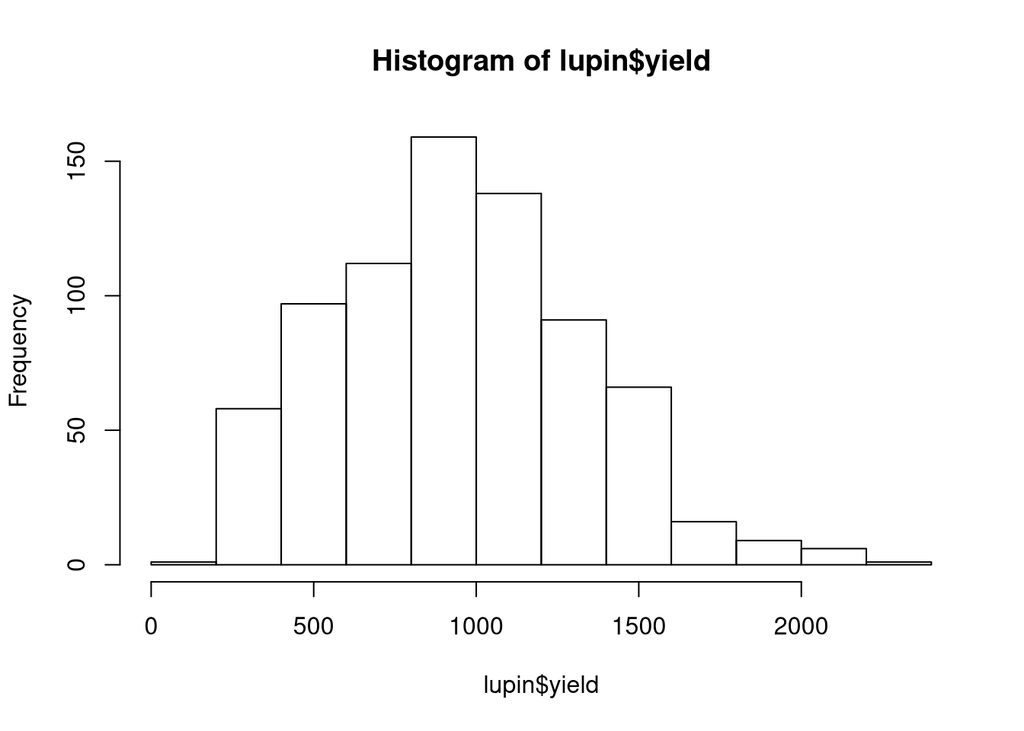

```r
hist(lupin$yield)
```

20. Get mean values of `harvest` by `rep2`. (2 pts)

```r
aggregate(yield ~ rep2, lupin, mean)
```

```
##              rep2    yield
## 1 2nd replication 944.2853
## 2          Others 957.6472
```

21. Find mean values of `harvest` for each `loc`. (2 pts)

```r
aggregate(yield ~ loc, lupin, mean)
```

```
##           loc     yield
## 1    Corrigin 1077.4703
## 2     Mullewa  613.2025
## 3   Newdegate 1075.0309
## 4 WonganHills  998.1621
```

22. Draw boxplots of the values of `harvest` of each `loc`. (1 pts)

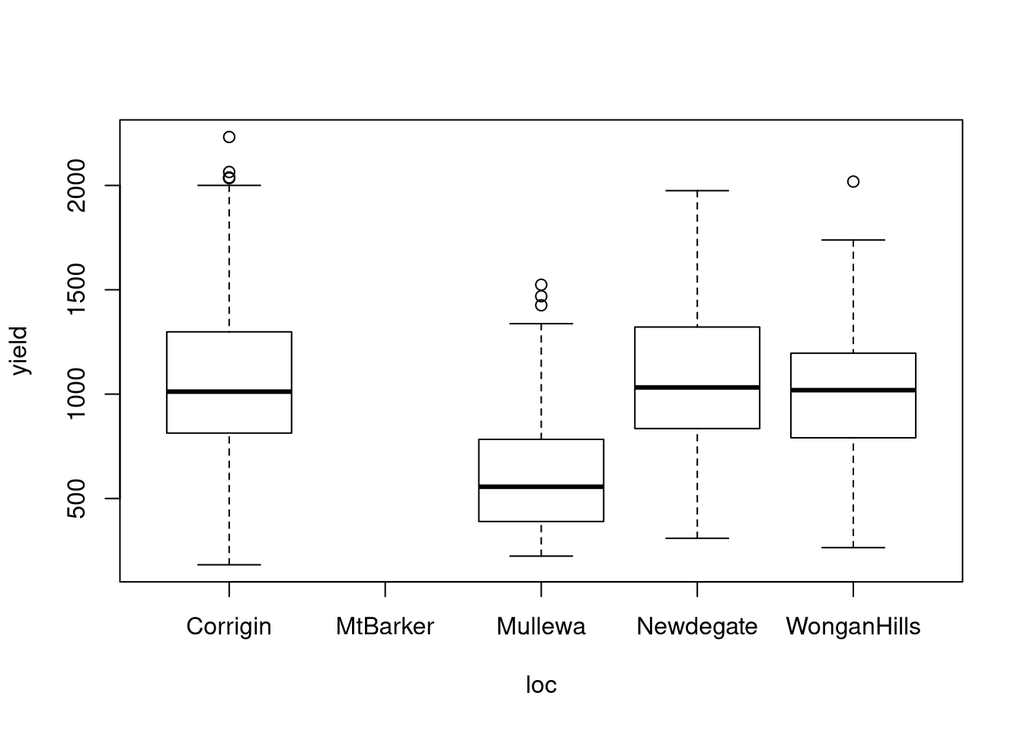

```r
boxplot(yield ~ loc, lupin)
```

# 4 Testing differences in means

23. Test if mean harvest is different for *2nd replication* and *Others*. (2 pts)

```r
t.test(yield ~ rep2, lupin)
```

```
##
##  Welch Two Sample t-test
##
## data:  yield by rep2
## t = -0.46959, df = 625.23, p-value = 0.6388
## alternative hypothesis: true difference in means is not equal to 0
## 95 percent confidence interval:
##  -69.24007  42.51625
## sample estimates:
## mean in group 2nd replication          mean in group Others
##                      944.2853                      957.6472
```

24. Is there a difference? Why? (3 pts)
25. Test if mean harvest differs by `loc`. (2 pts)

```r
summary(aov(yield ~ loc, lupin))
```

```
##              Df   Sum Sq Mean Sq F value Pr(>F)
## loc           3 24450832 8150277   71.76 <2e-16 ***
## Residuals   750 85186808  113582
## ---
## Signif. codes:  0 '***' 0.001 '**' 0.01 '*' 0.05 '.' 0.1 ' ' 1
```

26. Is any of the locations in `loc` different from others in mean harvest? Why? (3 pts)

# 5 Correlation

27. Plot the relationship between `harvest` and `rate` as boxes. (1 pt)

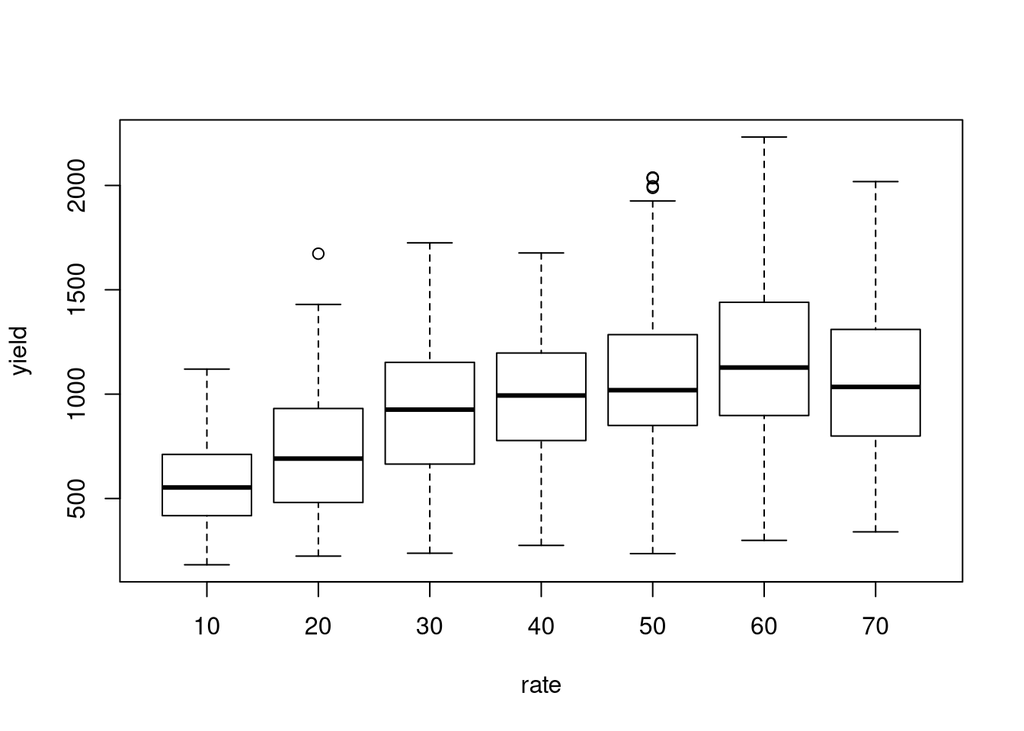

```r
boxplot(yield ~ rate, lupin)
```

28. Find Pearson’s correlation coefficient between `harvest` and `rate`. (1 pt)

```r
cor(lupin$yield, lupin$rate, use = 'complete.obs', method = 'pearson')
```

```
## [1] 0.4066256
```

29. How would you describe this relationship by the plot and correlation coefficient? (2 pts)

# 6 Regression modelling

We expect `harvest` to be higher when more seeds are sown (`rate`).

## 6.1 Estimate an OLS regression model

30. Estimate an OLS regression model where `harvest` depends on `rate`. Store and see the model. (2 pts)

```r
ylMod <- lm(yield ~ rate, lupin)
summary(ylMod)
```

```
##
## Call:
## lm(formula = yield ~ rate, data = lupin)
##
## Residuals:
##     Min      1Q  Median      3Q     Max
## -862.25 -237.35  -19.46  234.32 1116.95
##
## Coefficients:
##             Estimate Std. Error t value Pr(>|t|)
## (Intercept) 590.0616    32.2963   18.27   <2e-16 ***
## rate          8.7499     0.7169   12.21   <2e-16 ***
## ---
## Signif. codes:  0 '***' 0.001 '**' 0.01 '*' 0.05 '.' 0.1 ' ' 1
##
## Residual standard error: 348.8 on 752 degrees of freedom
## Multiple R-squared:  0.1653, Adjusted R-squared:  0.1642
## F-statistic:   149 on 1 and 752 DF,  p-value: < 2.2e-16
```

31. What is the theoretical harvest when rate is 0? (2 pts)
32. How many kg/ha harvest increases when seeding rate increases by 1 plant/m^2? (2 pts)
33. How much of the variance in harvest is explained by the model? (2 pts)

## 6.2 See how well the model fits

34. Plot the relationship between `harvest` and `rate` as points and add the regression line of the model. (1 pt)

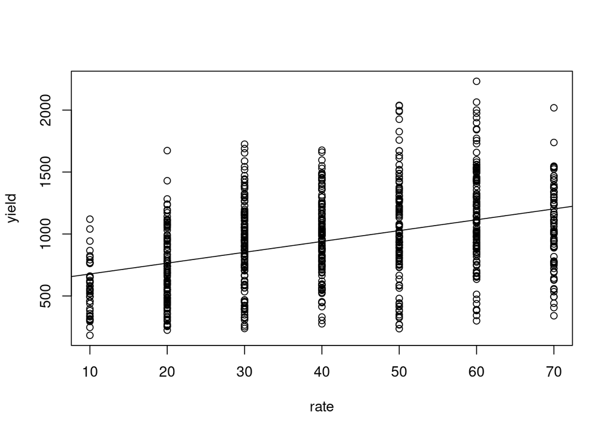

```r
plot(yield ~ rate, lupin)
abline(ylMod)
```

35. Deciding by the plot, does the model fit data well? Why? (2 pts)
36. Plot residuals against fitted values. (1 pt)

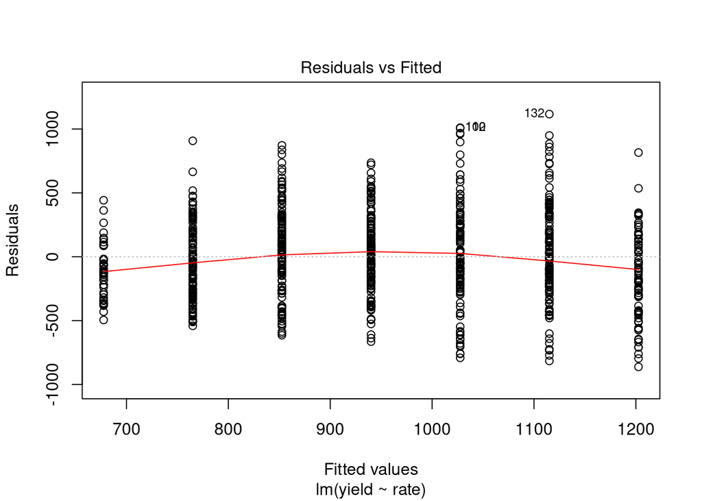

```r
plot(ylMod, 1)
```

37. Is the variance of the residuals constant? Why? (2 pts)
38. Draw QQ-plot of standardized residuals (1 pt)

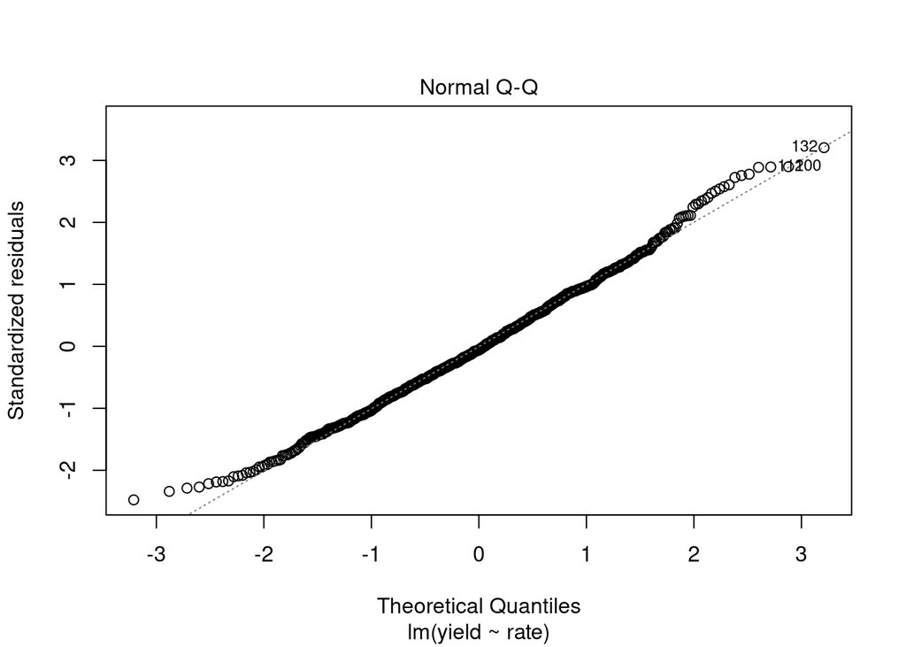

```r
plot(ylMod, 2)
```

39. Are residuals normally distributed? Why? (2 pts)

## 6.3 Estimate a multivariate OLS regression model

40. Estimate another model where you also add `loc` as a predictor. Store and see the model. (2 pts)

```r
ylMod2 <- lm(yield ~ rate + loc, lupin)
summary(ylMod2)
```

```
##
## Call:
## lm(formula = yield ~ rate + loc, data = lupin)
##
## Residuals:
##     Min      1Q  Median      3Q     Max
## -754.47 -208.11  -26.44  182.54  964.92
##
## Coefficients:
##                 Estimate Std. Error t value Pr(>|t|)
## (Intercept)     655.2402    30.4481  21.520  < 2e-16 ***
## rate             10.1973     0.5954  17.126  < 2e-16 ***
## locMullewa     -502.4976    28.8422 -17.422  < 2e-16 ***
## locNewdegate     63.9715    34.6952   1.844  0.06560 .
## locWonganHills  -80.0753    25.6045  -3.127  0.00183 **
## ---
## Signif. codes:  0 '***' 0.001 '**' 0.01 '*' 0.05 '.' 0.1 ' ' 1
##
## Residual standard error: 285.9 on 749 degrees of freedom
## Multiple R-squared:  0.4417, Adjusted R-squared:  0.4387
## F-statistic: 148.1 on 4 and 749 DF,  p-value: < 2.2e-16
```

The baseline value of `loc` is *Corrigin*.

41. How do you interpret the intercept now? (2 pts)
42. How do you interpret the coefficient for `locMullewa`? (2 pts)
43. How do you interpret the coefficient for `locNewdegate`? (2 pts)
44. Test if the two models you estimated are different. (1 pt)

```r
anova(ylMod, ylMod2)
```

```
## Analysis of Variance Table
##
## Model 1: yield ~ rate
## Model 2: yield ~ rate + loc
##   Res.Df      RSS Df Sum of Sq      F    Pr(>F)
## 1    752 91509670
## 2    749 61215324  3  30294345 123.56 < 2.2e-16 ***
## ---
## Signif. codes:  0 '***' 0.001 '**' 0.01 '*' 0.05 '.' 0.1 ' ' 1
```

45. Is the second model different from first? How? (2 pts)